# Splines and Smoothing

If we let $\tau_l$ denote the left boundary knot, we have $h_{1j}(\tau_l)=0$ for all $j=1,\ldots,4$ (this is by definition). Thus, $\tau_l$ serves at the ``baseline” value (similar to if we use dummy coding) for the effect of $X$. All $\beta$ values will be relative the the impact at $\tau_l$.

The variance the total coefficient for abdomen at when abdomen$=X$ is given by
$$H_1(X)'Cov(\beta_1)H_1(X),$$
which we’ll transform to standard error then plot $\pm 2SE$.

First, let’s get $\beta_1=(\beta_{11},\ldots,\beta_{14})'$

```r
abd_coef <- coef(B_spline_mod)[2:5]
```

Now, we’ll get the $X$ values we want to get the coefficient and SE for:

```r
# Values on the abdomen scale
abd_vec <- seq(min(bf_dat$abdomen),max(bf_dat$abdomen),length.out = 100)
# Values on the expansion scale (note the knots and Boundary.knots)
H1_mat <- bs(abd_vec,knots = attr(abdomen_bs,"knots"), Boundary.knots =
               attr(abdomen_bs,"Boundary.knots"))
```

Now, we’ll calculate the coefficient and SE for all $X$ values

```r
abd_beta <- H1_mat%*%abd_coef
cov_b1 <- vcov(B_spline_mod)[2:5,2:5]
abd_beta_se <- sqrt(diag(H1_mat%*%cov_b1%*%t(H1_mat)))
```

We’ll add $\pm 2SE$ to the coefficient and then plot

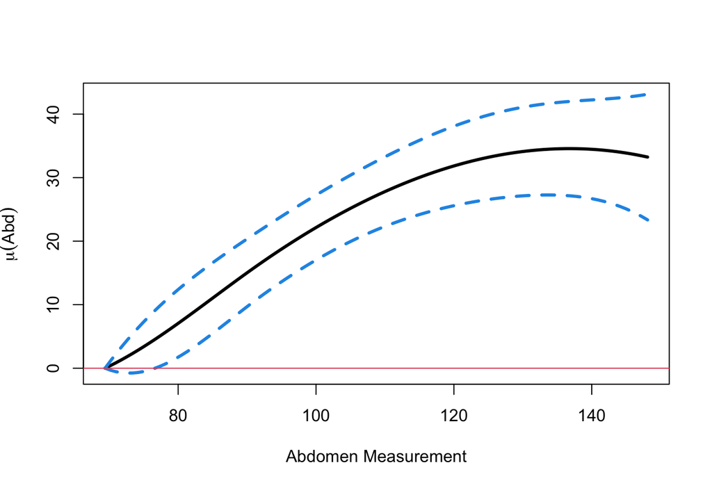

```r
l_limit_abd <- abd_beta - 1.96*abd_beta_se
u_limit_abd <- abd_beta + 1.96*abd_beta_se
abd_res <- data.frame(abd_beta,l_limit_abd,u_limit_abd)
matplot(abd_vec,abd_res,type = "l",col=c(1,4,4), lwd=3, lty=c(1,2,2),
        xlab=c("Abdomen Measurement"),ylab = expression(mu(Abd)))
abline(h=0,col=2)
```

Note that this plots the **total** effect of abdomen, not the effect of changing the value of abdomen by 1 unit.

To get the impact of changing abdomen by 1 unit, we can look at:

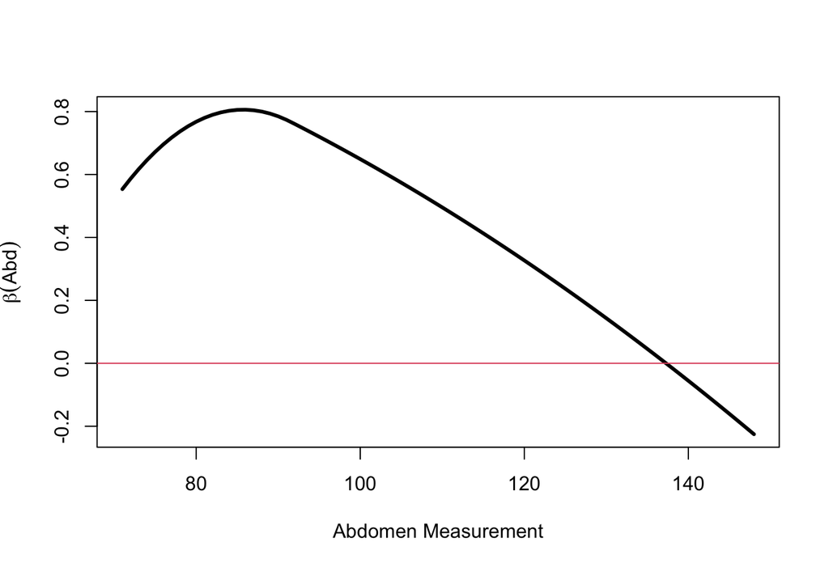

```r
abd_vec <- seq(
  ceiling(min(bf_dat$abdomen)),
  floor(max(bf_dat$abdomen)),
  by = 1)
# Values on the expansion scale (note the knots and Boundary.knots)
H1_mat <- bs(abd_vec,knots = attr(abdomen_bs,"knots"), Boundary.knots =
               attr(abdomen_bs,"Boundary.knots"))
abd_beta <- H1_mat%*%abd_coef

effect_of_abd <- abd_beta[-1] - abd_beta[-length(abd_beta)]


plot(abd_vec[-1],
     effect_of_abd,
     type = "l",
     lwd=3,
     xlab=c("Abdomen Measurement"),
     ylab = expression(beta(Abd)))
abline(h=0,col=2)
```

## Example 2: Using smothing splines

Let’s return to the first example, but this time we’ll fit the model using penalized splines. Recall from the notes that the penalized RSS can be written as
$$RSS(f,\lambda) = (y -
{N}\theta)'(y - {N}\theta)+\lambda \theta' \Omega_N
\theta$$
where ${N}_{ij} = N_j(x_i)$ and $\{\Omega_N\}_{jk} = \int N_j^{\prime \prime}(t)N_k^{\prime \prime}(t)dt$. The solution is given by
$$\hat{\theta}=({N}'{N} + \lambda
\Omega_N)^{-1}{N}'y$$

Here, we will give the model to the bodyfat example using the package. The function in the package does not let the user specify the $\lambda$ parameter. Here, the $\lambda$ parameter is selected using REML. For more details on the function in the package see https://stat.ethz.ch/R-manual/R-devel/library/mgcv/html/gam.html.

The nice thing about these plots it that they come with confidence intervals.

```r
b <- gam(bodyfat~s(abdomen, bs="bs", m=c(3,2)) +
           s(height,bs="bs",m=c(3,2)) +
           s(age,bs="bs",m=c(3,2)),
         data=bf_df_subset,
         method="REML")
summary(b)
```

```
##
## Family: gaussian
## Link function: identity
##
## Formula:
## bodyfat ~ s(abdomen, bs = "bs", m = c(3, 2)) + s(height, bs = "bs",
##     m = c(3, 2)) + s(age, bs = "bs", m = c(3, 2))
##
## Parametric coefficients:
##             Estimate Std. Error t value Pr(>|t|)
## (Intercept)  19.1508     0.2785   68.78   <2e-16 ***
## ---
## Signif. codes:  0 '***' 0.001 '**' 0.01 '*' 0.05 '.' 0.1 ' ' 1
##
## Approximate significance of smooth terms:
##              edf Ref.df       F  p-value
## s(abdomen) 3.505  4.273 133.469  < 2e-16 ***
## s(height)  1.000  1.000  28.445 3.05e-07 ***
## s(age)     1.001  1.002   1.032    0.311
## ---
## Signif. codes:  0 '***' 0.001 '**' 0.01 '*' 0.05 '.' 0.1 ' ' 1
##
## R-sq.(adj) =  0.721   Deviance explained = 72.7%
## -REML = 727.88  Scale est. = 19.54     n = 252
```

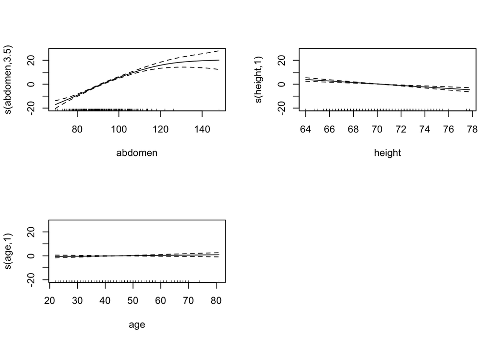

```r
plot(b,pages=1)
```

## Example 3: Using two-dimensional tensor regression

We’ll now look at an example which fits a multidimensional smoothing spline using *tensor product basis*. This action will be performed using the package we discussed in the last example.

```r
#Fit an ANOVA type tensor product interaction
b2 <- gam(bodyfat~ ti(abdomen) + ti(height) + ti(abdomen,height),
          data=bf_df_subset,
          method = "REML")
summary(b2)
```

```
Family: gaussian
Link function: identity

Formula:
bodyfat ~ ti(abdomen) + ti(height) + ti(abdomen, height)

Parametric coefficients:
            Estimate Std. Error t value Pr(>|t|)
(Intercept)  19.2282     0.2821   68.17   <2e-16 ***
---
Signif. codes:  0 '***' 0.001 '**' 0.01 '*' 0.05 '.' 0.1 ' ' 1

Approximate significance of smooth terms:
                     edf Ref.df       F p-value
ti(abdomen)        3.012  3.479 181.162  <2e-16 ***
ti(height)         1.000  1.001  36.254  <2e-16 ***
ti(abdomen,height) 1.711  2.123   2.237   0.105
---
Signif. codes:  0 '***' 0.001 '**' 0.01 '*' 0.05 '.' 0.1 ' ' 1

R-sq.(adj) =  0.724   Deviance explained = 73.1%
-REML =  726.5  Scale est. = 19.301    n = 252
```

```r
#Estimated smoothing parameters for the model.
b2$sp
```

```
        ti(abdomen)          ti(height) ti(abdomen,height)1 ti(abdomen,height)2
       1.049624e+01        8.667933e+05        2.256283e+05        5.601665e-01
```

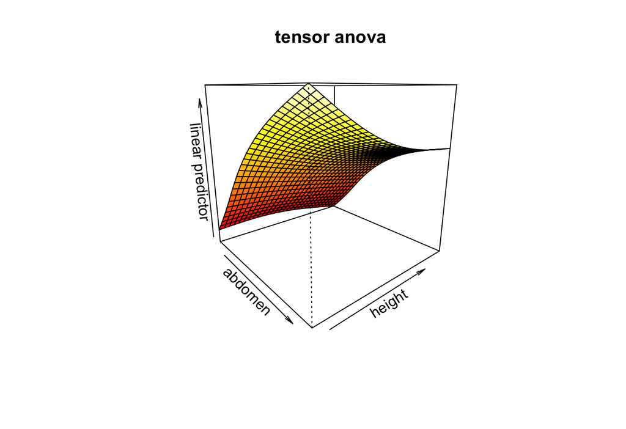

```r
#Plot the results.
vis.gam(b2, theta = 50);title("tensor anova")
```